# HW6

Given that the 90% HDI overlap for National and Local driving, it is inconclusive which drivers have better driving habits.

```r
#   Of the next hundred drivers what are the number of texting drivers in the 90% HDI?
n = 100
s = 0:n
pred.probs = pbetap(final.posterior, n, s)
plot(s, pred.probs, type = "h",
     main = "Distribution of # Local drivers texting at intersection (next 100 drivers)", xlab = "# of People texting at intersection", ylab = "Probability of Texting")
discint(cbind(s, pred.probs),0.90)
```

```
## $prob
## [1] 0.9098956
##
## $set
##  [1]  4  5  6  7  8  9 10 11 12 13 14 15 16 17 18 19 20
```

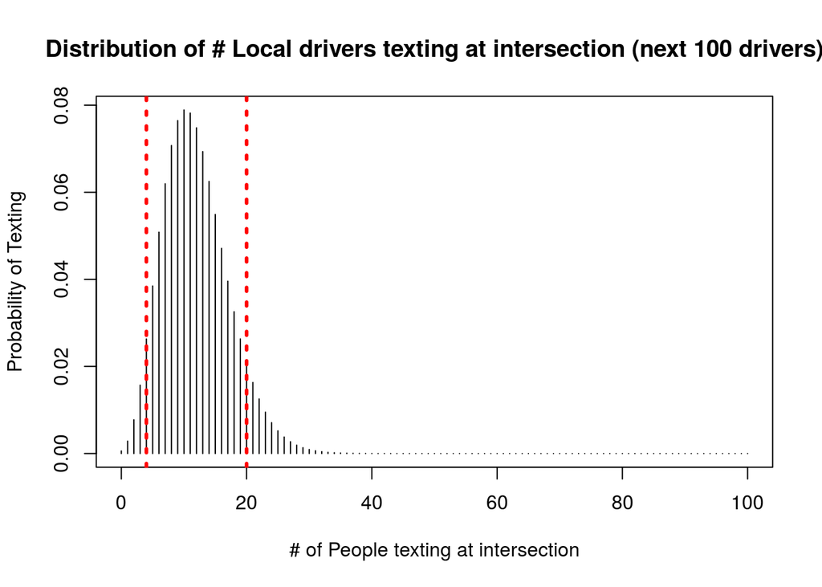

```r
interval = discint(cbind(s, pred.probs),0.90)$set
abline(v = interval[1], lty = 3, col = "red", lwd = 3)
abline(v = interval[length(interval)], lty = 3, col = "red", lwd = 3)
```

```r
expected.crashes = sum(pred.probs*s)
expected.crashes
```

```
## [1] 11.92469
```

For the local driving: Out of next 100 drivers, there is 90% chance that the actual number of drivers texting while at intersection is beteen 4-20

```r
#Are the drivers in this area better or worse that the national figures indicate?
n = 100
s = 0:n
pred.probs.national = pbetap(beta.prior, n, s)
plot(s, pred.probs.national, type = "h",
     main = "Distribution of # of National Drivers texting at intersection", xlab = "# of People texting at intersection", ylab = "Probability of Texting")
discint(cbind(s, pred.probs.national),0.90)
```

```
## $prob
## [1] 0.9038973
##
## $set
##  [1]  0  1  2  3  4  5  6  7  8  9 10 11 12 13 14 15 16 17 18 19 20 21 22
## [24] 23 24 25 26 27 28 29 30 31 32 33 34 35 36 37 38 39 40 41 42 43 44 45
## [47] 46 47 48 49 50 51 52 53 54 55
```

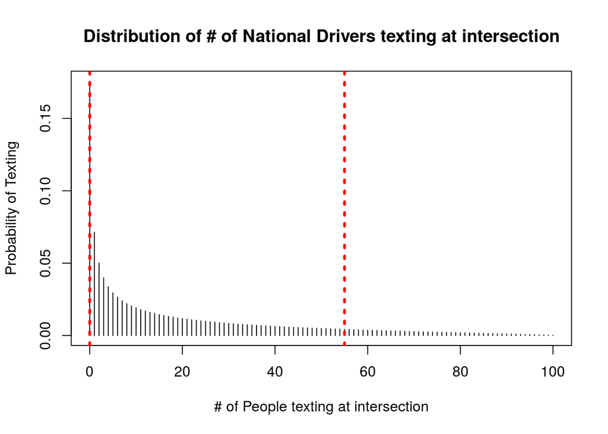

```r
interval = discint(cbind(s, pred.probs.national),0.90)$set
abline(v = interval[1], lty = 3, col = "red", lwd = 3)
abline(v = interval[length(interval)], lty = 3, col = "red", lwd = 3)
```

```r
expected.crashes.national = sum(pred.probs.national*s)
expected.crashes.national
```

```
## [1] 19.15888
```

For the National drivers: Out of next 100 drivers, there is 90% chance that the actual number of drivers texting while at intersection is beteen 0-55

Given that the 90% HDI overlap for National and Local driving, it is inconclusive which drivers have better driving habits.